# 1·比赛，梧桐杯智慧生活赛道

# 2·读书：d2l，3.14-4.6

### ·正向传播和反向传播

```
·正向传播沿着从输⼊层到输出层的顺序，依次计算并存储神经⽹络的中间变量。
·反向传播沿着从输出层到输⼊层的顺序，依次计算并存储神经⽹络中间变量和参数的梯度。
```

### ·MLP

##### 这⾥定义的 MLP 类重载了Module 类的 **init** 函数和 forward 函数，我们可以实例化 MLP 类得到模型变量 net 。下⾯的代码初始化 net 并传⼊输⼊数据 X 做⼀次前向计算。其中， net(X) 会调⽤ MLP 继承⾃ Module 类的 **call** 函数，这个函数将调⽤ MLP 类定义的forward 函数来完成前向计算。

```python
import torch
from torch import nn
class MLP(nn.Module):
    # 声明带有模型参数的层，这⾥声明了两个全连接层
    def __init__(self, **kwargs):
        # 调⽤MLP⽗类Block的构造函数来进⾏必要的初始化。这样在构造实例时还可以指定其他函数
        # 参数，如“模型参数的访问、初始化和共享”⼀节将介绍的模型参数params
        super(MLP, self).__init__(**kwargs)
        self.hidden = nn.Linear(784, 256) # 隐藏层
        self.act = nn.ReLU()
        self.output = nn.Linear(256, 10) # 输出层

    # 定义模型的前向计算，即如何根据输⼊x计算返回所需要的模型输出
    def forward(self, x):
        a = self.act(self.hidden(x))
        return self.output(a)
X = torch.rand(2, 784)
net = MLP()
print(net)
net(X)
```

```
MLP(
  (hidden): Linear(in_features=784, out_features=256, bias=True)
  (act): ReLU()
  (output): Linear(in_features=256, out_features=10, bias=True)
)
```

```
tensor([[ 0.0954, -0.0523,  0.0193,  0.1747, -0.1561, -0.1733, -0.1214, -0.0748,
         -0.1370,  0.0013],
        [ 0.0952, -0.1395,  0.1130,  0.2723, -0.1506, -0.0753, -0.1098, -0.0535,
          0.0257,  0.0089]], grad_fn=<AddmmBackward0>)
```

### ·模型参数

#### 访问模型参数

```python
print(type(net.named_parameters()))
for name, param in net.named_parameters():
    print(name, param.size())
```

```
<class 'generator'>
hidden.weight torch.Size([256, 784])
hidden.bias torch.Size([256])
output.weight torch.Size([10, 256])
output.bias torch.Size([10])
```

### ·读写 TENSOR

我们可以直接使⽤ save 函数和 load 函数分别存储和读取 Tensor 。 save 使⽤Python的pickle实⽤ 程序将对象进⾏序列化，然后将序列化的对象保存到disk，使⽤ save 可以保存各种对象,包括模型、张 量和字典等。⽽ laod 使⽤pickle unpickle⼯具将pickle的对象⽂件反序列化为内存。下面我们将tensor保存

```python
import torch
from torch import nn
x = torch.ones(3)
torch.save(x, 'x.pt')
```

然后我们可以再次读取数据

```python
x2 = torch.load('x.pt')
x2
```

```
tensor([1., 1., 1.])
```

我们还可以存储⼀个 Tensor 列表并读回内存

```python
y = torch.zeros(4)
torch.save([x, y], 'xy.pt')
xy_list = torch.load('xy.pt')
xy_list
```

```
[tensor([1., 1., 1.]), tensor([0., 0., 0., 0.])]
```

### ·保存和加载模型

```python
class MLP(nn.Module):
    def __init__(self):
        super(MLP, self).__init__()
        self.hidden = nn.Linear(3, 2)
        self.act = nn.ReLU()
        self.output = nn.Linear(2, 1)
    def forward(self, x):
        a = self.act(self.hidden(x))
        return self.output(a)
net = MLP()
net.state_dict()
```

```
OrderedDict([('hidden.weight',
              tensor([[ 0.2569,  0.3520, -0.1283],
                      [-0.0399, -0.4659,  0.0037]])),
             ('hidden.bias', tensor([-0.1679, -0.4229])),
             ('output.weight', tensor([[0.2538, 0.5295]])),
             ('output.bias', tensor([0.0910]))])
```

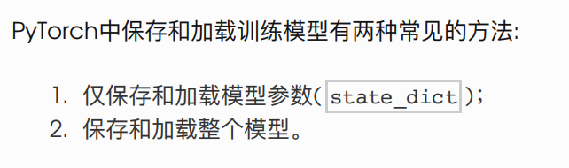

### ·方法1：保存和加载 state_dict (推荐⽅式)

#### 保存

```python
PATH = "./net.pt"
torch.save(net.state_dict(), PATH) # 推荐的⽂件后缀名是pt或pth
```

#### 加载

```
model = TheModelClass(*args, **kwargs)
model.load_state_dict(torch.load(PATH))
```

### ·方法二：保存整个模型

#### 保存

torch.save(model, PATH)

#### 加载

model = torch.load(PATH)

例如：

```python
# 保存模型
X = torch.randn(2, 3)
Y = net(X)
PATH = "./net.pt"
torch.save(net.state_dict(), PATH)
```

```python
# 加载模型
net2 = MLP()
net2.load_state_dict(torch.load(PATH))
Y2 = net2(X)
Y2 == Y
```

```
tensor([[True],
        [True]])
```

### 将tensor放到GPU上,如果对在GPU上的数据进⾏运算，那么结果还是存放在GPU上。

```python
x = torch.tensor([1, 2, 3])
x = x.cuda(0)
x
```

```
tensor([1, 2, 3], device='cuda:0')
```

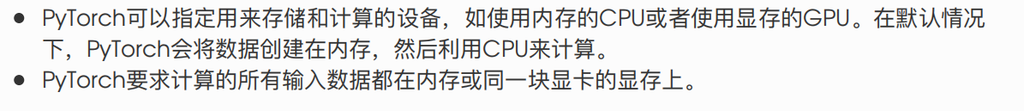

# 3·手动实现二维卷积，多输入通道，多输出通道

```python
import torch
import numpy as np
import torch.nn as nn
import d2lzh_pytorch as d2l
```

### 单输入通道，单输出通道：

```python
# 单通道输入，一个卷积核
def corr2d(X,K):
    h,w = K.shape
    res = torch.zeros([X.shape[0]-h+1,X.shape[1]-w+1])
    for i in range(res.shape[0]):
        for j in range(res.shape[1]):
            res[i,j] = (X[i:i+h,j:j+w]*K).sum()
    return res

X = torch.tensor([[0, 1, 2], [3, 4, 5], [6, 7, 8]])
K = torch.tensor([[0, 1], [2, 3]])
res = corr2d(X=X,K=K)
res
```

```
tensor([[19., 25.],
        [37., 43.]])
```

### 多输入通道：多个输入，一个输出

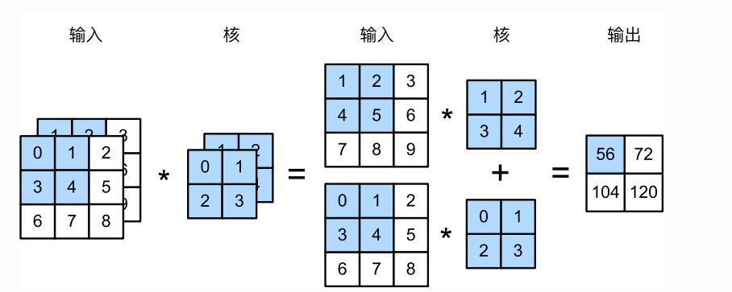

```python
# 多通道输入对应多个卷积核
X = torch.tensor([[[0, 1, 2], [3, 4, 5], [6, 7, 8]],[[1, 2, 3], [4, 5, 6], [7, 8, 9]]])
K = torch.tensor([[[0, 1], [2, 3]], [[1, 2], [3, 4]]])
def mult_in(X,K):
        res = corr2d(X[0,:,:],K[0,:,:])
        for i in range(1,K.shape[0]):
            res+=corr2d(X[i,:,:],K[i,:,:])
        return res
res = mult_in(X,K)
print(res)
```

```
tensor([[ 56.,  72.],
        [104., 120.]])
```

### 多输出通道：多个输出，一个输入

```python
# 多个卷积核
X = torch.tensor([[0, 1, 2], [3, 4, 5], [6, 7, 8]])
K = torch.tensor([[[0, 1], [2, 3]], [[1, 2], [3, 4]]])

def mult_out(X,K):
    out = []
    res = corr2d(X,K[0,:,:])
    out.append(res)
    for i in range(1,K.shape[0]):
        out.append(corr2d(X,K[i,:,:]))
    return out
mult_out(X,K)
```

```
[tensor([[19., 25.],
         [37., 43.]]),
 tensor([[27., 37.],
         [57., 67.]])]
```

# 4·说一说你对填充和步幅的理解：

填充：填充可以增加输出的⾼和宽，对于一般的神经网络，我们在使用卷积核进行提取特征时，会导致边缘处只检测了部分像素点，丢失了图片边界处的众多信息，没有完整的提取边缘特征

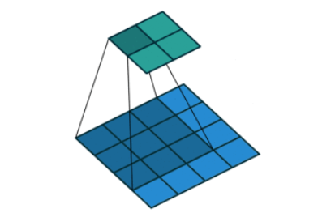

当我们填充之后，卷积核，就可以充分的利用边缘特征

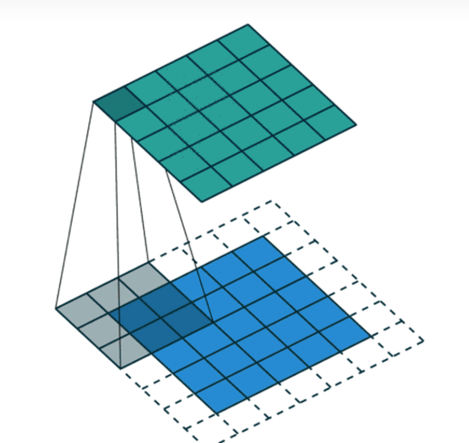

步幅：是指的卷积核滑动的补步长，步幅可以减⼩输出的⾼和宽，同时也在计算时减少了运算

# 5·说一说1X1卷积核的作用

### 增加网络的深度，可以加入激活函数,增加非线性因素，因此提高了泛化能力，同时使用1X1的卷积核，相比于其他卷积核能够提高计算速度